# DiffCorr: Analyzing and Visualizing Differential Correlation Networks in Transcriptomic and Metabolomic Data

Atsushi Fukushima

Kyoto Prefectural University/RIKEN  
afukushima@gmail.com

2025-06-08

DiffCorr [1-2] is a package for identifying pattern changes between 2 experimental conditions in correlation networks (e.g., gene co-expression networks), which builds on a commonly used association measure, such as Pearson’s correlation coefficient. This document demonstrates typical correlation network analysis using transcriptome and metabolome data.

# Installation

## Release version ([CRAN](https://cran.r-project.org/)):

```r
install.packages("DiffCorr")
```

## Development version ([Github](https://github.com/afukushima/DiffCorr/)):

```r
install.packages("devtools")
install.packages(c("igraph", "fdrtool"))

if (!requireNamespace("BiocManager", quietly = TRUE))
    install.packages("BiocManager")
BiocManager::install(c("pcaMethods", "multtest"))

library(devtools)
install_github("afukushima/DiffCorr")
```

# Introduction

Molecular interactions can be modeled as networks by measuring associations between molecules in omics data. Gene co-expression analysis, commonly based on transcriptome datasets from microarray experiments and RNA-seq, uses metrics like Pearson’s correlation coefficient to quantify these relationships.

When gene correlations surpass a threshold, they form co-expression or correlation networks. These analyses, often using a “guide-gene” approach [3], offer insights into regulatory mechanisms and have been used to identify genes involved in plant secondary metabolisms.

In addition to identifying differentially expressed genes (DEGs) between samples, changes in correlation patterns, or “differential correlations,” provide insights into molecular interactions [4]. Differential network analysis, which compares networks (e.g., normal vs. diseased), has been applied to both plant and animal studies and has been useful in metabolomics for understanding complex metabolic processes.

This document demonstrate typical correlation network analysis using transcriptome and metabolome data. It also showcases the utility of the DiffCorr [1-2] package by identifying biologically relevant, differentially correlated molecules in transcriptome co-expression and metabolite-to-metabolite correlation networks.

```r
library(DiffCorr)
```

# DiffCorr for Golub’s data (ALL/AML leukemia dataset)

This section was created from [Additional File 3](https://sourceforge.net/projects/diffcorr/files/AdditionalFile3.txt/download) included in the original DiffCorr package. As an example, we use Golub’s data (https://coxpress.sourceforge.net/golub.txt). The dataset consist of gene expression profiles from 38 tumor samples including 2 different leukemia subtypes: 27 acute lymphoblastic leukemia (ALL) and 11 acute myeloid leukemia (AML) samples (Golub et al., 1999). The microarray platform used, Affymetrix GeneChip HuGeneFL (known as HU6800), contains 6800 probe-sets. To demonstrate the usefulness of DiffCorr package, we describe and discuss the results from analysis of the transcriptomic dataset.

## Reading the Golub dataset

```r
data(golub.df)
dim(golub.df)
```

```
#> [1] 2568   38
```

## Clusters on each subset

```r
hc.mol1 <- cluster.molecule(golub.df[, 1:27], "pearson", "average")  ## ALL (27 samples)
hc.mol2 <- cluster.molecule(golub.df[, 28:38], "pearson", "average") ## AML (11 samples)
```

## Cut the tree at a correlation of 0.6 using cutree function

```r
g1 <- cutree(hc.mol1, h = 0.4)
g2 <- cutree(hc.mol2, h = 0.4)
res1 <- get.eigen.molecule(data = golub.df, groups = g1)
```

```
#> [1] 1
#> [1] 2
#> [1] 3
#> [1] 4
#> [1] 5
#> [1] 6
#> [1] 7
#> [1] 8
#> [1] 9
#> [1] 10
#> [1] 11
#> [1] 12
#> [1] 13
#> [1] 14
#> [1] 15
#> [1] 16
#> [1] 17
#> [1] 18
#> [1] 19
#> [1] 20
#> [1] 21
#> [1] 22
```

```r
res2 <- get.eigen.molecule(data = golub.df, groups = g2)
```

```
#> [1] 1
#> [1] 2
#> [1] 3
#> [1] 4
#> [1] 5
#> [1] 6
#> [1] 7
#> [1] 8
#> [1] 9
#> [1] 10
#> [1] 11
#> [1] 12
#> [1] 13
#> [1] 14
#> [1] 15
```

[output cut: 72 more lines]

## Visualizing module networks

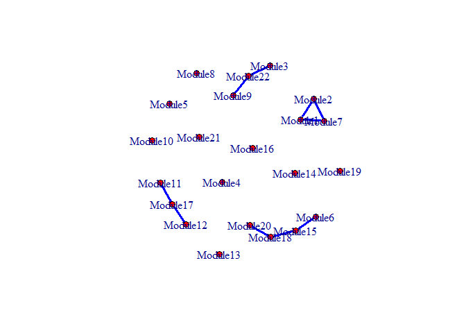

```r
gg1 <- get.eigen.molecule.graph(res1)
plot(gg1, layout = layout.fruchterman.reingold(gg1))
```

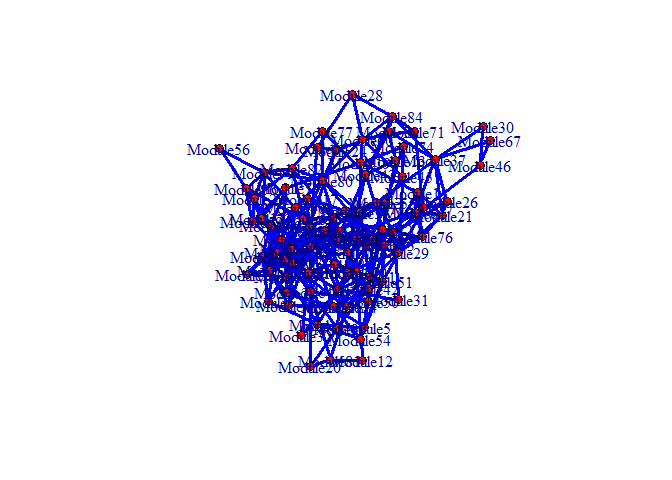

```r
gg2 <- get.eigen.molecule.graph(res2)
plot(gg2, layout = layout.fruchterman.reingold(gg2))
```

You can save the results.

```r
write.modules(g1, res1, outfile = "module1_list.txt")
write.modules(g2, res2, outfile = "module2_list.txt")
```

You can examine the relationship between modules.

```r
for (i in 1:length(res1$eigen.molecules)) {
  for (j in 1: length(res2$eigen.molecules)) {
    r <- cor(res1$eigen.molecules[[i]],res2$eigen.molecules[[j]], method = "spearman")
    if (abs(r) > 0.8) {
      print(paste("(i, j): ", i, " ", j, sep = ""))
      print(r)
    }
  }
}
```

```
#> [1] "(i, j): 2 8"
#> [1] 0.830303
#> [1] "(i, j): 4 83"
#> [1] 0.8424242
#> [1] "(i, j): 5 86"
#> [1] 0.8787879
#> [1] "(i, j): 10 56"
#> [1] -0.8666667
#> [1] "(i, j): 10 63"
#> [1] -0.8545455
#> [1] "(i, j): 13 47"
#> [1] -0.8060606
#> [1] "(i, j): 13 87"
#> [1] 0.8181818
#> [1] "(i, j): 21 24"
#> [1] -0.9515152
```

```r
cor(res1$eigen.molecules[[2]], res2$eigen.molecules[[8]], method = "spearman")
```

```
#> [1] 0.830303
```

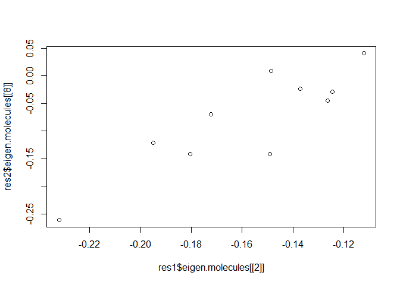

```r
plot(res1$eigen.molecules[[2]], res2$eigen.molecules[[8]])
```

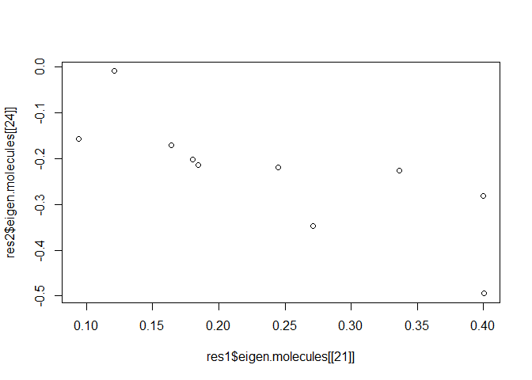

```r
plot(res1$eigen.molecules[[21]], res2$eigen.molecules[[24]])
```

## Examine groups of interest graphically

look at groups 21 and 24

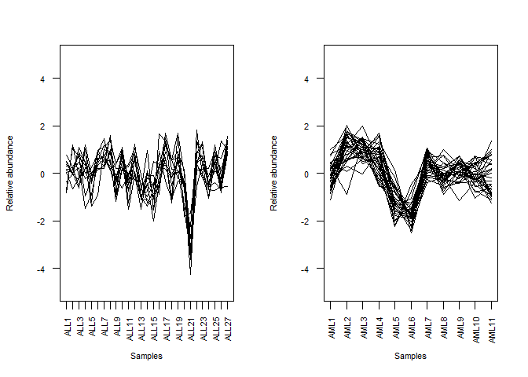

```r
plotDiffCorrGroup(golub.df, g1, g2, 21, 24, 1:27, 28:38,
                    scale.center = TRUE, scale.scale = TRUE,
                    ylim=c(-5,5))
```

## Export the results (FDR < 0.05)

```r
comp.2.cc.fdr(output.file = "res.txt", golub.df[, 1:27], golub.df[, 28:38], threshold = 0.05, save = TRUE)
```

# Exploring the metabolome data of flavonoid-deficient Arabidopsis

Kusano et al. [5] studied flavonoid-deficient *Arabidopsis thaliana* (Arabidopsis) mutants and wild-type plants using gas chromatography-mass spectrometry (GC-MS) for metabolite profiling [5-6]. The mutant, *transparent testa 4* (*tt4*), lacks chalcone synthase (CHS), a key enzyme in the flavonoid biosynthesis pathway, and is unable to produce flavonoids, which protect plants from UV-B radiation.

## `AraMetLeaves` dataset

`AraMetLeaves` includes metabolite profiles of 37 aerial part samples, consisting of 17 Columbia-0 wild-type (Col-0) and 20 *tt4* plants, covering a wide range of primary metabolites. The dataset `AraMetLeaves` is available in the DiffCorr package.

```r
data(AraMetLeaves)
dim(AraMetLeaves)
```

```
#> [1] 59 50
```

The `AraMetLeaves` dataset contains 59 metabolites (rows) and 50 observations (columns). For comparison with data from aerial parts [5-6], we selected 59 commonly detected metabolites across both datasets using MetMask (https://metmask.sourceforge.net). It is important to note that another genotype, *mto1*, is also present in the data matrix. For further information, refer to the help page of `AraMetLeaves`.

```r
colnames(AraMetLeaves)
```

```
#>  [1] "Col0.1"  "Col0.2"  "Col0.3"  "Col0.4"  "Col0.5"  "Col0.6"  "Col0.7"
#>  [8] "Col0.8"  "Col0.9"  "Col0.10" "Col0.11" "Col0.12" "Col0.13" "Col0.14"
#> [15] "Col0.15" "Col0.16" "Col0.17" "tt4.1"   "tt4.2"   "tt4.3"   "tt4.4"
#> [22] "tt4.5"   "tt4.6"   "tt4.7"   "tt4.8"   "tt4.9"   "tt4.10"  "tt4.11"
#> [29] "tt4.12"  "tt4.13"  "tt4.14"  "tt4.15"  "tt4.16"  "tt4.17"  "tt4.18"
#> [36] "tt4.19"  "tt4.20"  "mto1.1"  "mto1.2"  "mto1.3"  "mto1.4"  "mto1.5"
#> [43] "mto1.6"  "mto1.7"  "mto1.8"  "mto1.9"  "mto1.10" "mto1.11" "mto1.12"
#> [50] "mto1.13"
```

```r
?AraMetLeaves
```

## Differential correlation analysis for *tt4* mutant and the wild-type plants

Differential correlation between *tt4* and Col-0 can be performed as follows:

```r
comp.2.cc.fdr(output.file = "Met_DiffCorr_res.txt",
              log10(AraMetLeaves[, 1:17]),   ## Col-0 (17 samples)
              log10(AraMetLeaves[, 18:37]),  ## tt4 (20 samples)
              method = "pearson",
              threshold = 1.0, save = TRUE)
```

**Table 1.** A typical result of pairwise differential correlations from the DiffCorr package. The full list can be found in [1].

| molecule X | molecule Y | r1 | p1 | r2 | p2 | p (difference) | (r1-r2) | lfdr (in cond. 1) | lfdr (in cond. 2) | lfdr (difference) |
| --- | --- | --- | --- | --- | --- | --- | --- | --- | --- | --- |
| Malate | Threonine | 0.77 | 0.00034 | 0.94 | 1.5E-09 | 0.057 | -0.17 | 0.0049 | 3.2E-08 | 0.76 |
| Malate | Phenylalanine | 0.45 | 0.070 | 0.89 | 1.2E-07 | 0.0086 | -0.44 | 0.20 | 2.2E-06 | 0.64 |

# Conclusion

The R package DiffCorr provides a straightforward and efficient framework for detecting differential correlations between two conditions in omics data, utilizing Fisher’s z-test. It is a useful tool for inferring potential relationships and identifying biomarker candidates. Based on the concept of “differential network biology,” DiffCorr [1, 5] is applicable not only to metabolomic data but also to transcriptome, proteome, and integrated omics datasets.

# References

1. Fukushima, Gene (2013) https://doi.org/10.1016/j.gene.2012.11.028
2. Fukushima and Nishida “Using the DiffCorr Package to Analyze and Visualize Differential Correlations in Biological Networks” - Book chapter in “Challenges of Computational Network Analysis with R”. Editors: Matthias Dehmer, Yongtang Shi, and Frank Emmert-Streib. WILEY.
3. Saito et al. Trends Plant Sci (2008) https://doi.org/10.1016/j.tplants.2007.10.006
4. de la Fuente, Trends Genet (2010) https://doi.org/10.1016/j.tig.2010.05.001
5. Kusano et al. BMC Syst Biol (2007) https://doi.org/10.1186/1752-0509-1-53
6. Fukushima et al. BMC Syst Biol (2011) https://doi.org/10.1186/1752-0509-5-1
7. Kusano et al. Plant J (2011) https://doi.org/10.1111/j.1365-313x.2011.04599.x